# Proyecciones de población del estado de Chihuahua, Méx. para el periodo 2016-2050.

Trabajo final de la asignatura Análisis Demográfico III

Achicanoy Romero Natalia; Arcos Bulos Raquel; Ortiz Balcázar Jorge Luis

## Introducción

El presente trabajo tiene como objetivo proyectar la población del estado de Chihuahua, Méx. en el periodo de 35 años comprendido entre 2016 y 2050 con base en las metodologías estudiadas en la asignatura Análisis Demográfico III que consideran la evolución futura de los tres fenómenos demográficos que repercuten en la dinámica de población (mortalidad, fecundidad y migración).

Las proyecciones de población se definen como el escenario hipotético de lo que ocurriría con la dinámica demográfica de un país o región si determinadas circunstancias económicas, políticas, sociales y demográficas llegasen a ocurrir (García-Guerrero 2019).

Permiten que tanto las instituciones locales como las federales puedan implementar un sistema integral de planeación prospectiva y estratégica, que asegure la suficiencia y acceso a los servicios básicos que la población requiere para su desarrollo y bienestar. Asimismo se utilizan para la repartición estatal y municipal de recursos, la elaboración del Programa Nacional de Desarrollo (PND), del Programa Nacional de Población~(PNP), de diversas encuestas del INEGI e informes sexenales (García-Guerrero 2019).

Para la elaboración de las proyeccciones, la población inicial se obtuvo del ejercicio de **Conciliación Demográfica de México (CD)**, más reciente, que abarca el periodo 1950-2015 para el nivel nacional y 1970-2015 para las entidades federativas. Este ejercicio, a cargo del Consejo Nacional de Población de México (CONAPO), es un requerimiento básico para obtener estimaciones futuras; consiste en armonizar las tendencias de las componentes demográficas (mortalidad, fecundidad y migración) con la población por edad y sexo enumerada en las siguientes fuentes: 1) los censos de población desde 1950 hasta 2010; 2) los conteos de población de 1995 y 2005; 3) la Encuesta Intercensal (EIC) de 2015; 4) encuestas especializadas y 5) registros administrativos (CONAPO 2016).

## Contexto en Chihuahua

En el año 2015, el estado de Chihuahua ocupó la undécima posición a nivel nacional con respecto al número de habitantes que alberga, haciendo de ella una de las entidades con mediana población. De acuerdo con la CD, en ese año la población de la entidad era de 3,616,481 habitantes y de acuerdo con la EIC 2015 era de 3,556,574 habitantes (CONAPO 2016).

## Métodos

Para elaborar las proyecciones, se utilizó el métodos de Lee y Carter, el cual combina un modelo demográfico con pocos supuestos y con métodos estadísticos de series de tiempo, por ello, provee una base estocástica al pronóstico de la mortalidad, así como intervalos de predicción (García Guerrero and Mellado 2012). Este modelo parte del supuesto de que existe una relación lineal entre el logaritmo natural de las Tasas Específicas de Mortalidad (TEM) y dos factores que las determinan: la edad y el tiempo.

### Series de tiempo

Una serie de tiempo es una secuencia de observaciones en una variable que se mide en puntos sucesivos en el tiempo. El patrón de datos es un factor importante en la comprensión de cómo las series de tiempo se han comportado en el pasado. Si se espera que tal comportamiento continúe en el futuro, se puede utilizar el patrón anterior como guía en la selección de un método de elaboración de pronósticos adecuado.

El objetivo del análisis de series de tiempo es descubrir un patrón en los datos históricos o de *series de tiempo* para después extrapolar el modelo al futuro. El pronóstico se basa únicamente en los valores pasados de la variable o en los errores de pronóstico del pasado (Anderson 2012).

Con fines de claridad, a partir de este momento nos referiremos al periodo 1970-2015 como periodo base y al periodo 2016-2050 como periodo proyectado.

## Fecundidad

Las Tasas Específicas de Fecundidad en el periodo base están dadas en grupos de edad quinquenales, por lo que fue necesario desagruparlas en edades simples utilizando el método de la investigadora Heather Booth (Booth 1984).

Como primer paso para la desagregación, se calculan las **Tasas Globales de Fecundidad (TGF)** con base en edades agrupadas para el periodo base. Las siguiente tabla muestra los resultados de dicho cálculo.

```
## 1970 1971 1972 1973 1974 1975 1976 1977 1978 1979 1980 1981 1982 1983 1984 1985
##  6.1  5.9  5.8  5.6  5.4  5.2  5.0  4.8  4.6  4.4  4.2  4.1  3.9  3.8  3.7  3.5
## 1986 1987 1988 1989 1990 1991 1992 1993 1994 1995 1996 1997 1998 1999 2000 2001
##  3.4  3.3  3.3  3.3  3.2  3.1  3.1  3.0  2.9  2.9  2.8  2.7  2.7  2.6  2.6  2.6
## 2002 2003 2004 2005 2006 2007 2008 2009 2010 2011 2012 2013 2014 2015
##  2.5  2.5  2.5  2.5  2.5  2.4  2.4  2.4  2.4  2.4  2.3  2.3  2.2  2.2
```

Una vez aplicado el método de desagrupación de edades, se obtienen las **Tasas Específicas de Fecundidad (TEF)** por *edades simples* para el periodo base. En la Gráfica 1 se visualizan estas tasas.

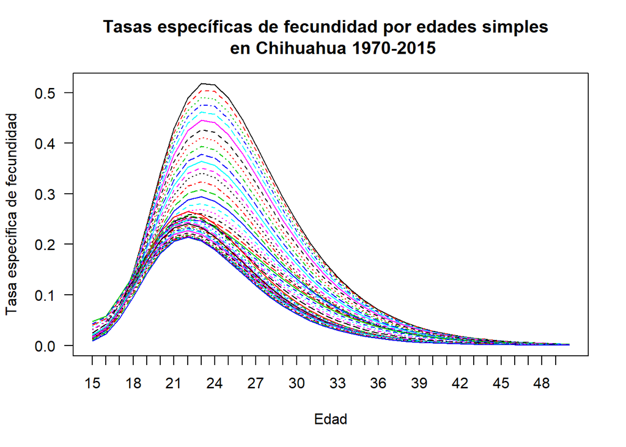

Gráfica 1

Para el periodo base, a continuación se presenta la edad en la que la **Tasa Específica de Fecundidad** alcanzó su máximo. Vemos que esta edad máxima prácticamente no varió en un largo intervalo de 46 años, concentrándose únicamente en dos edades de las mujeres, a saber 22 y 23 años.

```
## 1970 1971 1972 1973 1974 1975 1976 1977 1978 1979 1980 1981 1982 1983 1984 1985
## "23" "23" "23" "23" "23" "23" "23" "23" "23" "23" "23" "23" "23" "23" "23" "23"
## 1986 1987 1988 1989 1990 1991 1992 1993 1994 1995 1996 1997 1998 1999 2000 2001
## "23" "23" "23" "23" "22" "22" "22" "22" "22" "22" "22" "22" "22" "22" "22" "22"
## 2002 2003 2004 2005 2006 2007 2008 2009 2010 2011 2012 2013 2014 2015
## "22" "22" "22" "22" "22" "22" "22" "22" "22" "22" "22" "22" "22" "22"
```

```
##
##  ARIMA(2,1,2) with drift         : -20
##  ARIMA(0,1,0) with drift         : -7.2
##  ARIMA(1,1,0) with drift         : -27
##  ARIMA(0,1,1) with drift         : -20
##  ARIMA(0,1,0)                    : 18
##  ARIMA(2,1,0) with drift         : -25
##  ARIMA(1,1,1) with drift         : -25
##  ARIMA(2,1,1) with drift         : -23
##  ARIMA(1,1,0)                    : -24
##
##  Best model: ARIMA(1,1,0) with drift
```

[figure not shown]

## Mortalidad

La Gráfica 3 presenta las **Tasas Específicas de Mortalidad (TEM)** según sexo para el periodo base.

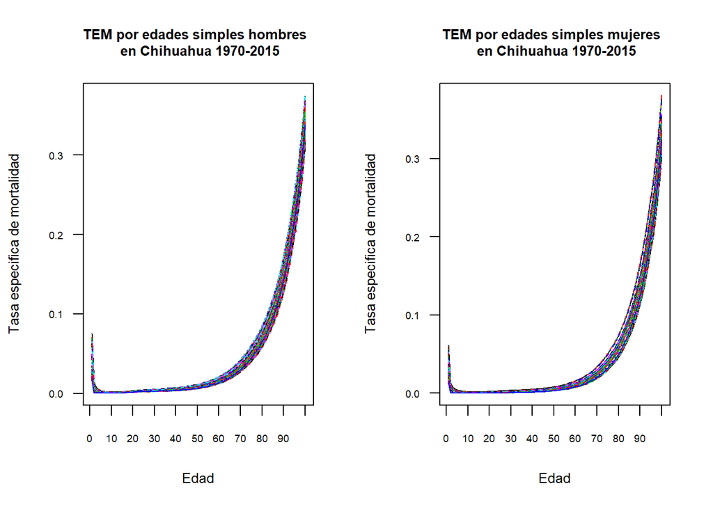

Gráfica 3

- Modelo ARIMA para la mortalidad. Se tomó en cuenta la serie histórica a partir de 1971.

```
##
##  ARIMA(2,1,2) with drift         : 38
##  ARIMA(0,1,0) with drift         : 45
##  ARIMA(1,1,0) with drift         : 34
##  ARIMA(0,1,1) with drift         : 38
##  ARIMA(0,1,0)                    : 70
##  ARIMA(2,1,0) with drift         : 35
##  ARIMA(1,1,1) with drift         : 33
##  ARIMA(2,1,1) with drift         : 36
##  ARIMA(1,1,2) with drift         : 36
##  ARIMA(0,1,2) with drift         : 39
##  ARIMA(1,1,1)                    : 33
##  ARIMA(0,1,1)                    : 52
##  ARIMA(1,1,0)                    : 35
##  ARIMA(2,1,1)                    : 35
##  ARIMA(1,1,2)                    : Inf
##  ARIMA(0,1,2)                    : 48
##  ARIMA(2,1,0)                    : 35
##  ARIMA(2,1,2)                    : 37
##
##  Best model: ARIMA(1,1,1)
```

```
## [1] "matrix"
```

[figure not shown]

## Migración

Los datos sobre migración internacional en la Conciliación Demográfica están agregados en grupos de edad quinquenales, por lo que se procedió a desagregarlos en edades simples utilizando el método de interpolación y suavizamiento de datos propuesto por Griffith Feeney (Feeney 2013). El método se basa en una medida de aspereza mínima (minimum roughness) que ofrece ventajas sobre los métodos de interpolación polinomial.

Se encontró en internet una plantilla del programa MS Excel http://demographer.com/dsitl/06-minimum-roughness-interpolation/ que posibilitó aplicar el método de Freeney a los datos de migración. Una vez que se obtuvo la desagregación, se procedió al cálculo de las Tasas Específicas de Migración hasta la edad 89, por ser ésta la última edad incluida en la información base. No obstante, a partir de la edad 81 los datos son cero por lo que se eliminaron los registros a partir de esa edad.

La Gráfica 5 muestra las **Tasas de migración internacional (TMI)** según sexo y dirección del movimiento.

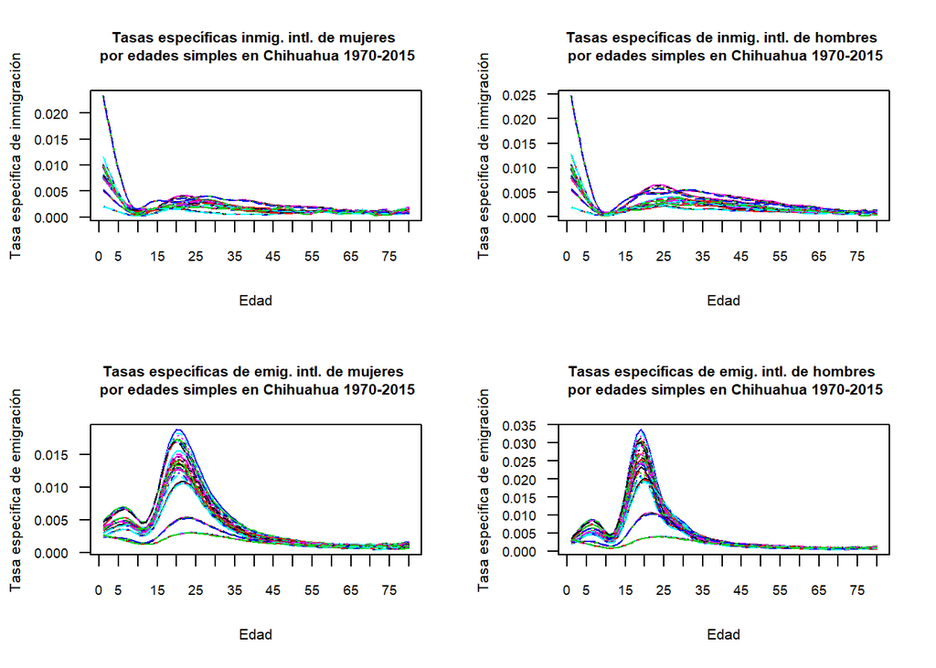

Gráfica 5

Modelos ARIMA para la migración internacional. Se tomó en cuenta la serie histórica a partir del año 2000.

- Modelo ARIMA para la inmigración de mujeres

```
##
##  ARIMA(2,1,2)                    : 163
##  ARIMA(0,1,0)                    : 154
##  ARIMA(1,1,0)                    : 156
##  ARIMA(0,1,1)                    : 156
##  ARIMA(1,1,1)                    : 158
##
##  Best model: ARIMA(0,1,0)
```

- Modelo ARIMA para la inmigración de hombres

```
##
##  ARIMA(2,1,2)                    : Inf
##  ARIMA(0,1,0)                    : 165
##  ARIMA(1,1,0)                    : 167
##  ARIMA(0,1,1)                    : 167
##  ARIMA(1,1,1)                    : 168
##
##  Best model: ARIMA(0,1,0)
```

- Modelo ARIMA para la emigración de mujeres

```
##
##  ARIMA(2,1,2)                    : 106
##  ARIMA(0,1,0)                    : 97
##  ARIMA(1,1,0)                    : 99
##  ARIMA(0,1,1)                    : 99
##  ARIMA(1,1,1)                    : 101
##
##  Best model: ARIMA(0,1,0)
```

- Modelo ARIMA para la emigración de hombres

```
##
##  ARIMA(2,2,2)                    : Inf
##  ARIMA(0,2,0)                    : 135
##  ARIMA(1,2,0)                    : 125
##  ARIMA(0,2,1)                    : 107
##  ARIMA(1,2,1)                    : 109
##  ARIMA(0,2,2)                    : 108
##  ARIMA(1,2,2)                    : Inf
##
##  Best model: ARIMA(0,2,1)
```

```
## [1] 110  35
```

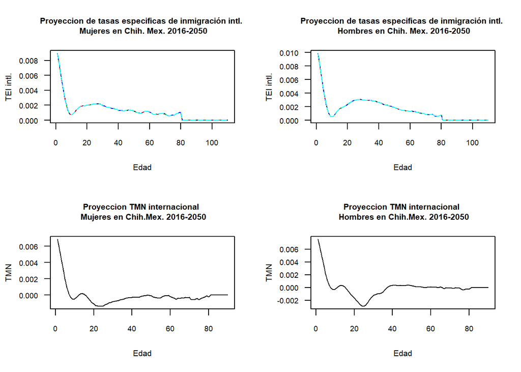

Gráfica 6

A continuación se presentan los valores utilizados como argumentos en las funciones Lee y Carter.

```
##        base   horizonte    fin_proy edades_mort  edades_fec  edades_mig
##        2015          35        2050         220          36          80
##  tiempo_tot tiempo_mort  tiempo_fec  tiempo_mig
##          81          46          46          45
```

##### Esperanzas de vida por edad y al nacimiento. Históricas y proyectadas

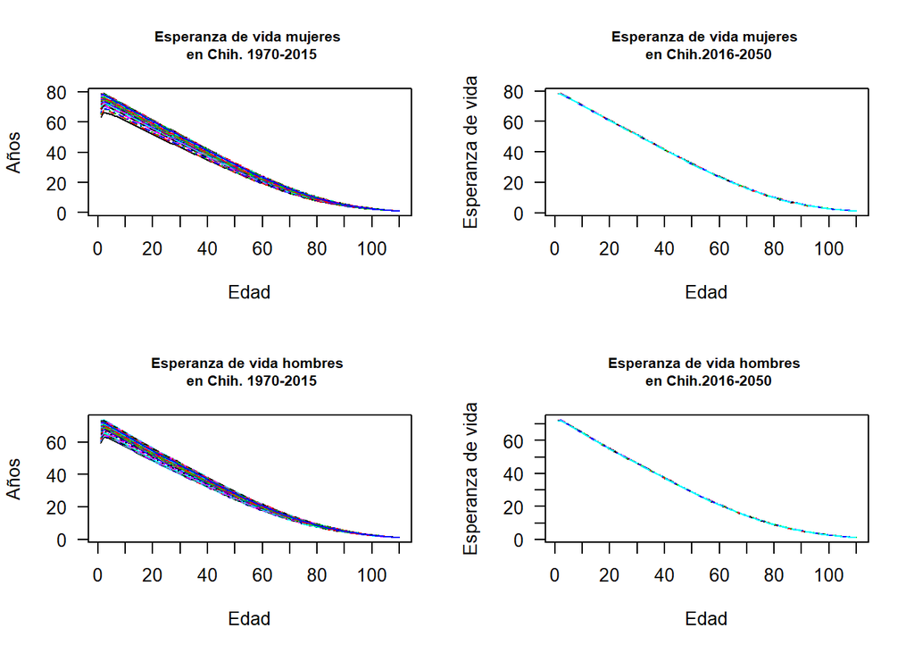

Gráfica 7

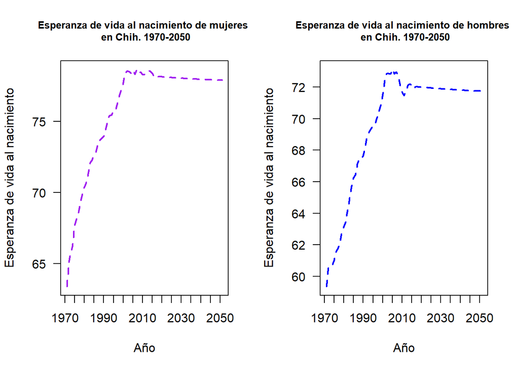

Gráfica 8

## References

Anderson, Dennis; Williams Thomas, David; Sweeney. 2012. *Estadistica Para Negocios Y Economia*. Mexico D.F: Cengage Learning.

Booth, Heather. 1984. “Transforming Gompertz’s Function for Fertility Analysis: The Development of a Standard for the Relational Gompertz Function.” *Population Studies* 38 (3): 495–506. https://doi.org/10.1080/00324728.1984.10410306.

CONAPO. 2016. “Proyecciones de La Población de México Y de Las Entidades Federativas, 2016-2050. Chihuahua.” CONAPO.

Feeney, Griffith. 2013. “Minimum Roughness: A New Approach to Interpolation and Smoothing.” 2013. http://demographer.com/dsitl/06-minimum-roughness-interpolation/.

García-Guerrero, Víctor M. 2019. “Apuntes Para La Asignatura Análisis Demográfico Iii.”

García Guerrero, Víctor, and Manuel Mellado. 2012. “Proyección Estocástica de La Mortalidad Mexicana Por Medio Del Método de Lee-Carter.” *Estudios Demográficos Y Urbanos* 27 (August): 409–48. https://doi.org/10.2307/41759686.